# ejercicio_clase_5

Noelí D’Alessio

```r
library(tidyverse)
library(psych)
library(expss)
```

1. Importar la tabla de datos a R

```r
library(haven)
Insomnio_2 <- read_sav("Insomnio_2.sav")
View(Insomnio_2)
```

Nueva variable donde guardar la base:

```r
dataInsomnio <- Insomnio_2
```

2. Incorporar etiquetas a todas las variables
3. Incorporar etiquetas a todos los valores de las variables, en el caso que tenga sentido realizar esta acción.

```r
dataInsomnio <- as_factor(dataInsomnio)
View(dataInsomnio)
```

4.Graficar las variables edad y sexo con el gráfico que crea conveniente.

```r
dataInsomnio %>%
  count(Edad)
```

```
## # A tibble: 3 x 2
##   Edad                   n
##   <fct>              <int>
## 1 Menor a 20 años       33
## 2 Entre 20 y 25 años    33
## 3 Mas de 25 años        33
```

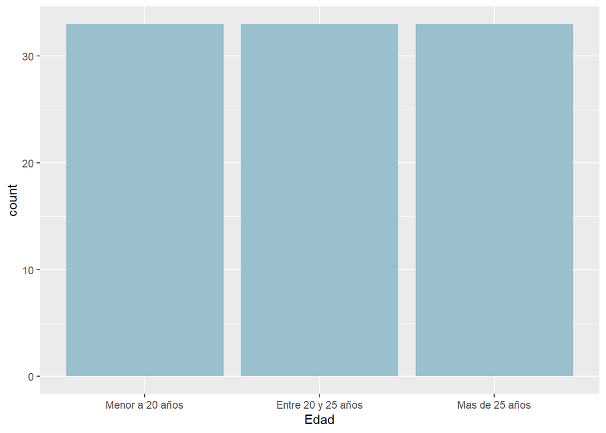

```r
ggplot(dataInsomnio, aes(Edad)) +
  geom_bar(fill = "lightblue3")
```

```r
dataInsomnio %>%
  count(Sexo)
```

```
## # A tibble: 2 x 2
##   Sexo       n
##   <fct>  <int>
## 1 Mujer     50
## 2 Hombre    49
```

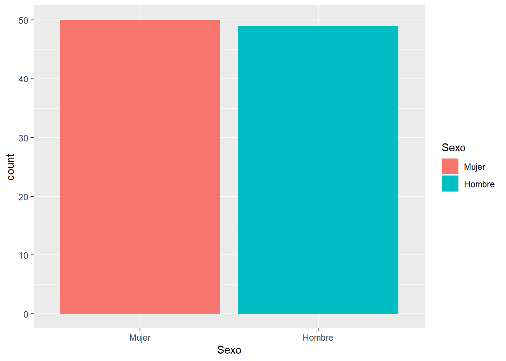

```r
ggplot(dataInsomnio, aes(Sexo, fill = Sexo)) +
  geom_bar()
```

5. Calcular estadísticos descriptivos convenientes para dichas variables

```r
describe(Insomnio_2$Edad)
```

```
##    vars  n mean   sd median trimmed  mad min max range skew kurtosis   se
## X1    1 99    2 0.82      2       2 1.48   1   3     2    0    -1.53 0.08
```

```r
describe(dataInsomnio, dataInsomnio$Edad, na.rm = TRUE)
```

```
##              vars  n  mean    sd median trimmed   mad  min   max range  skew
## Clave           1 99 50.00 28.72  50.00   50.00 37.06 1.00 99.00 98.00  0.00
## PrimerNoche     2 99  6.77  2.16   6.71    6.78  2.42 1.63 12.22 10.59 -0.02
## SegundaNoche    3 99  8.62  1.29   8.51    8.53  1.11 6.43 11.89  5.46  0.76
## TerceraNoche    4 99  6.99  2.37   6.68    6.91  2.49 2.38 12.71 10.33  0.31
## Sexo*           5 99  1.49  0.50   1.49    1.49  0.00 1.00  2.00  1.00  0.02
## Edad*           6 99  2.00  0.82   2.00    2.00  1.48 1.00  3.00  2.00  0.00
## Terapia1*       7 99  1.60  0.49   1.66    1.62  0.00 1.00  2.00  1.00 -0.39
## Terapia2*       8 99  1.60  0.49   1.66    1.62  0.00 1.00  2.00  1.00 -0.39
## Terapia3*       9 99  1.55  0.50   1.58    1.56  0.00 1.00  2.00  1.00 -0.18
##              kurtosis   se
## Clave           -1.24 2.89
## PrimerNoche     -0.46 0.22
## SegundaNoche     0.27 0.13
## TerceraNoche    -0.24 0.24
## Sexo*           -2.02 0.05
## Edad*           -1.53 0.08
## Terapia1*       -1.87 0.05
## Terapia2*       -1.87 0.05
## Terapia3*       -1.99 0.05
```

6. Hacer un gráfico de Boxplot por edad y sexo para cada una de las variables de cantidad de horas dormidas
- ggplot() + boxplot() PRIMER NOCHE + EDAD

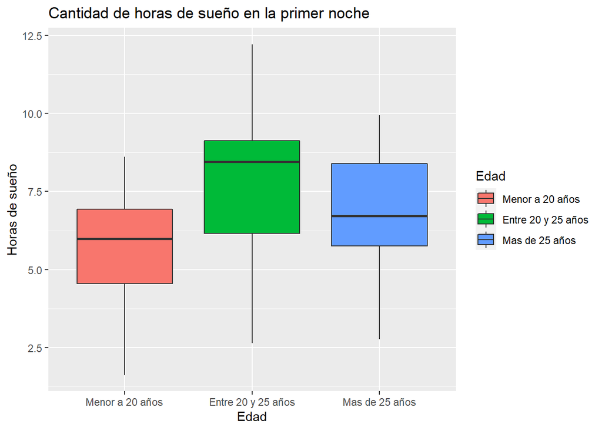

```r
ggplot(dataInsomnio) +
    geom_boxplot(aes(Edad, PrimerNoche, fill = Edad)) +
    ggtitle("Cantidad de horas de sueño en la primer noche") +
    ylab("Horas de sueño")
```

- ggplot() + boxplot() SEGUNDA NOCHE + EDAD

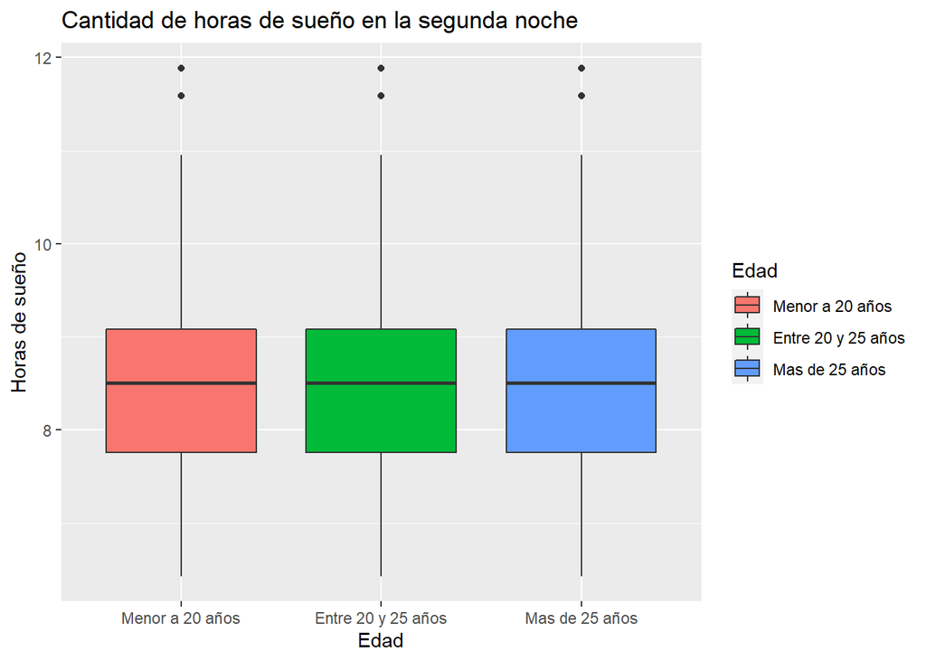

```r
ggplot(dataInsomnio) +
  geom_boxplot(aes(Edad, SegundaNoche, fill = Edad)) +
  ggtitle("Cantidad de horas de sueño en la segunda noche") +
  ylab("Horas de sueño")
```

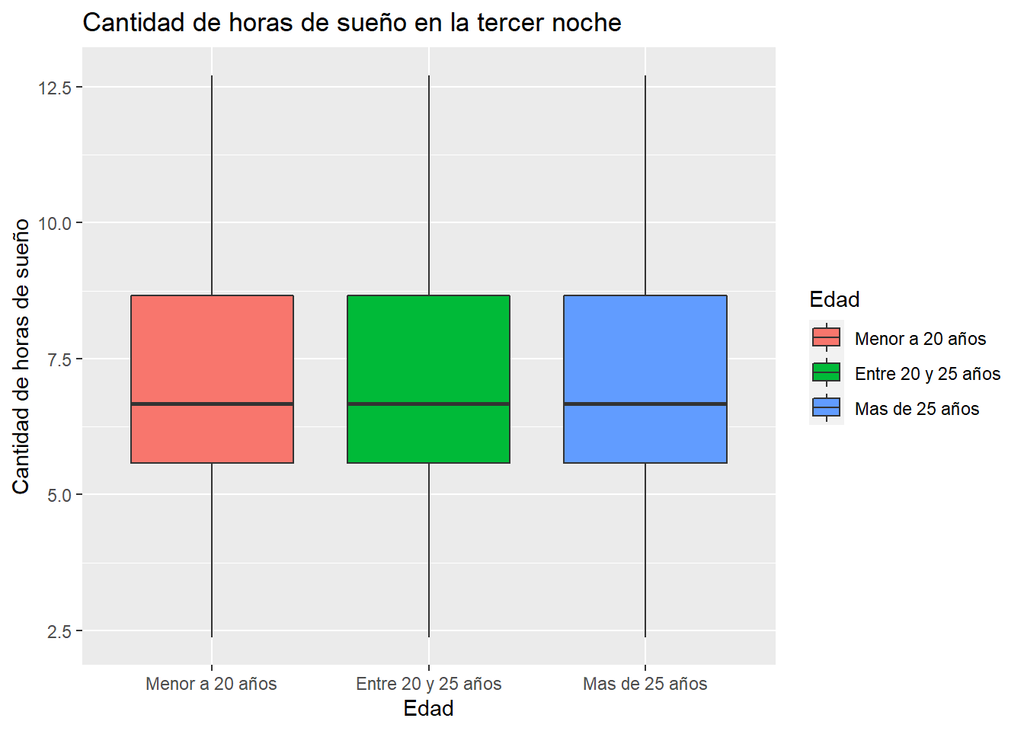

```r
ggplot(dataInsomnio, aes(Edad, TerceraNoche, fill = Edad)) +
    geom_boxplot() +
    ggtitle("Cantidad de horas de sueño en la tercer noche") +
    ylab("Cantidad de horas de sueño")
```

- boxplot() PRIMER NOCHE + EDAD

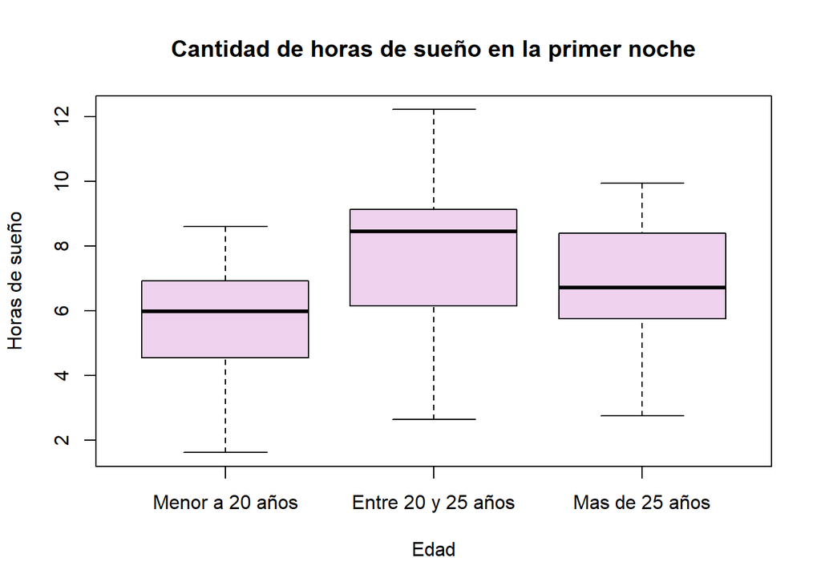

```r
boxplot(dataInsomnio$PrimerNoche~Edad, data = dataInsomnio, na.action = NULL,
        ylab = "Horas de sueño",
        xlab = "Edad",
        main = "Cantidad de horas de sueño en la primer noche",
        ann = TRUE,
        varwidth = TRUE,
        outline = TRUE,
        col = "thistle2")
```

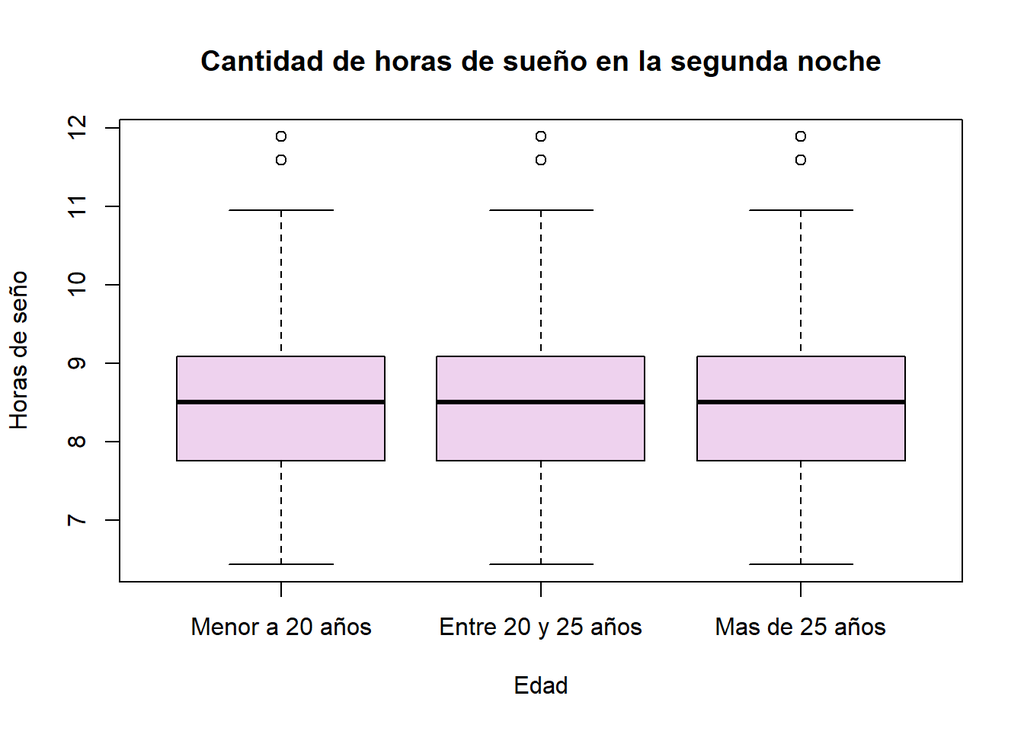

```r
boxplot(dataInsomnio$SegundaNoche~Edad, dataInsomnio, na.action = NULL,
        ylab = "Horas de seño",
        main = "Cantidad de horas de sueño en la segunda noche",
        ann = TRUE,
        varwidth = TRUE,
        outline = TRUE,
        col = "thistle2")
```

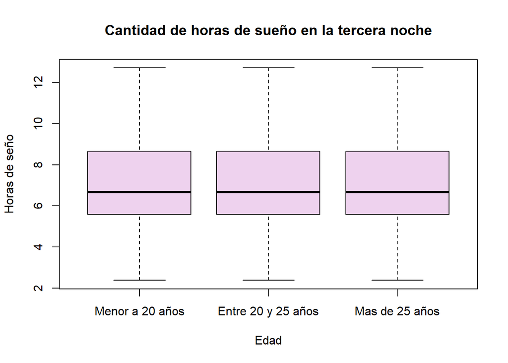

```r
boxplot(dataInsomnio$TerceraNoche~Edad, dataInsomnio, na.action = NULL,
        ylab = "Horas de seño",
        main = "Cantidad de horas de sueño en la tercera noche",
        ann = TRUE,
        varwidth = TRUE,
        outline = TRUE,
        col = "thistle2")
```

7. Hacer un gráfico de boxplot para los tres variables de cantidad de horas dormidas juntas (en un solo gráfico)
- ggplot() + boxplot()

Modifico tablas para que cada columna sea una variable. Por ejemplo, las columnas PrimeraNoche, SegundaNoche y TerceraNoche deberían ser valores de una varible “numeroNoche”. Los valores de estas columnas irían a otra variable “horasSueno”. Lo mismo ocurre con las variables Terapia1, Terapia2 y Terapia3.

```r
dataInsomnio2 <- dataInsomnio %>%
    pivot_longer(c(PrimerNoche, SegundaNoche, TerceraNoche),
                 names_to = "numeroNoche", values_to = "horasSueno") %>%
    pivot_longer(c(Terapia1, Terapia2, Terapia3),
                 names_to = "terapia", values_to = "realizoTerapia")

#rename(numeroNoche = c("Primer Noche", "Segunda Noche", "Tercera Noche"))

head(dataInsomnio2)
```

```
## # A tibble: 6 x 7
##   Clave Sexo  Edad            numeroNoche  horasSueno terapia  realizoTerapia
##   <dbl> <fct> <fct>           <chr>             <dbl> <chr>    <fct>
## 1     1 Mujer Menor a 20 años PrimerNoche        6.42 Terapia1 No
## 2     1 Mujer Menor a 20 años PrimerNoche        6.42 Terapia2 Si
## 3     1 Mujer Menor a 20 años PrimerNoche        6.42 Terapia3 No
## 4     1 Mujer Menor a 20 años SegundaNoche       7.70 Terapia1 No
## 5     1 Mujer Menor a 20 años SegundaNoche       7.70 Terapia2 Si
## 6     1 Mujer Menor a 20 años SegundaNoche       7.70 Terapia3 No
```

Ahora si, podemos realizar el boxplot con ggplot() + geom_boxplot()

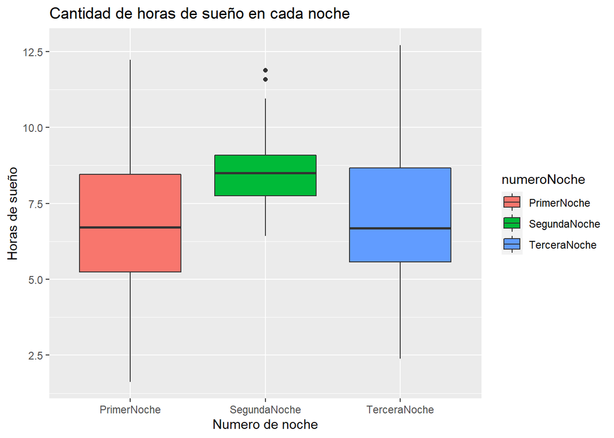

```r
ggplot(dataInsomnio2, aes(x = numeroNoche, y = horasSueno, fill = numeroNoche)) +
  geom_boxplot() +
  ggtitle("Cantidad de horas de sueño en cada noche") +
  ylab("Horas de sueño") +
  xlab("Numero de noche")
```

- Boxplot()

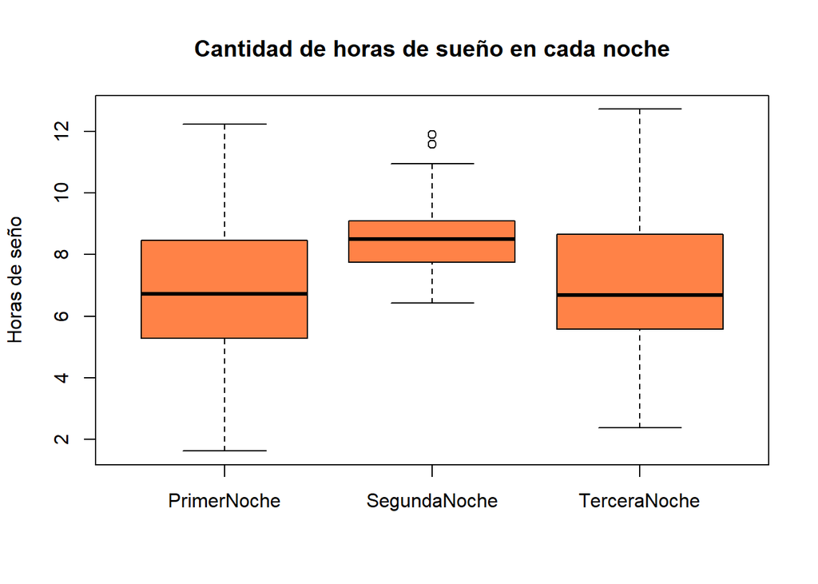

```r
boxplot(dataInsomnio[,c("PrimerNoche", "SegundaNoche", "TerceraNoche")],
        na.action = NULL,
        ylab = "Horas de seño",
        main = "Cantidad de horas de sueño en cada noche",
        ann = TRUE,
        varwidth = TRUE,
        outline = TRUE,
        col = "sienna1")
```

8. Calcular los estadísticos descriptivos para las variables de cantidad de horas dormidas por tipo de terapia que tuvo el paciente

```r
describeBy(dataInsomnio$PrimerNoche, dataInsomnio$Terapia1)
```

```
##
##  Descriptive statistics by group
## group: No
##    vars  n mean   sd median trimmed mad  min   max range skew kurtosis   se
## X1    1 40 6.93 2.43   6.99    6.88 2.8 1.63 12.22 10.59 0.05    -0.61 0.38
## ------------------------------------------------------------
## group: Si
##    vars  n mean   sd median trimmed  mad  min   max range skew kurtosis   se
## X1    1 59 6.67 1.97   6.62    6.71 2.04 2.63 10.04  7.41 -0.2    -0.73 0.26
```

9. (difícil). Crear una variable que indique qué combinación de terapias ha tenido cada paciente. La variable debe ser así: 0= ninguna terapia, 1=sólo terapia contra insomnio, 2=sólo terapia contra ansiedad, etc.

```r
dataInsomnio <-
  dataInsomnio %>%
  mutate(
    combinacionTerapia = case_when(
      Terapia1 == "No" & Terapia2 == "No" & Terapia3 == "No" ~ "ninguna",
      Terapia1 == "Si" & Terapia2 == "No" & Terapia3 == "No" ~ "insomnio",
      Terapia1 == "No" & Terapia2 == "Si" & Terapia3 == "No" ~ "ansiedad",
      Terapia1 == "No" & Terapia2 == "No" & Terapia3 == "Si" ~ "fobia",
      Terapia1 == "Si" & Terapia2 == "Si" & Terapia3 == "No" ~ "insomnio y ansiedad ",
      Terapia1 == "Si" & Terapia2 == "No" & Terapia3 == "Si" ~ "insomnio y fobia",
      Terapia1 == "No" & Terapia2 == "Si" & Terapia3 == "Si" ~ "ansiedad y fobia",
      Terapia1 == "Si" & Terapia2 == "Si" & Terapia3 == "Si" ~ "insomnio ansiedad fobia",
    )
  )
```

10. Calcular las frecuencias y graficar la variable anterior.

```r
fre(dataInsomnio$combinacionTerapia)
```

| dataInsomnio$combinacionTerapia | Count | Valid percent | Percent | Responses, % | Cumulative responses, % |
| --- | --- | --- | --- | --- | --- |
| ansiedad | 10 | 10.1 | 10.1 | 10.1 | 10.1 |
| ansiedad y fobia | 20 | 20.2 | 20.2 | 20.2 | 30.3 |
| fobia | 5 | 5.1 | 5.1 | 5.1 | 35.4 |
| insomnio | 15 | 15.2 | 15.2 | 15.2 | 50.5 |
| insomnio ansiedad fobia | 14 | 14.1 | 14.1 | 14.1 | 64.6 |
| insomnio y ansiedad | 15 | 15.2 | 15.2 | 15.2 | 79.8 |
| insomnio y fobia | 15 | 15.2 | 15.2 | 15.2 | 94.9 |
| ninguna | 5 | 5.1 | 5.1 | 5.1 | 100.0 |
| #Total | 99 | 100 | 100 | 100 |  |
| <NA> | 0 |  | 0.0 |  |  |

```r
dataInsomnio %>%
  count(combinacionTerapia) %>%
  mutate(prop = prop.table(n)*100) %>%
  mutate(prop = round(prop, 2))
```

```
## # A tibble: 8 x 3
##   combinacionTerapia            n  prop
##   <chr>                     <int> <dbl>
## 1 "ansiedad"                   10 10.1
## 2 "ansiedad y fobia"           20 20.2
## 3 "fobia"                       5  5.05
## 4 "insomnio"                   15 15.2
## 5 "insomnio ansiedad fobia"    14 14.1
## 6 "insomnio y ansiedad "       15 15.2
## 7 "insomnio y fobia"           15 15.2
## 8 "ninguna"                     5  5.05
```

11. Hacer un gráfico boxplot para cada una de las variables de horas dormidas, cruzando con la variable creada en 9)

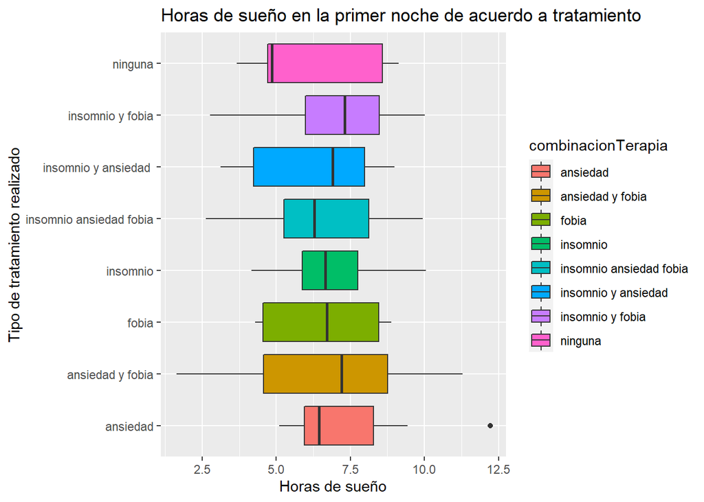

```r
ggplot(dataInsomnio, aes(combinacionTerapia, PrimerNoche, fill = combinacionTerapia)) +
    geom_boxplot() +
    ggtitle("Horas de sueño en la primer noche de acuerdo a tratamiento") +
    ylab("Horas de sueño") +
    xlab("Tipo de tratamiento realizado") +
    coord_flip()
```

```r
  #theme(axis.text.x = element_text(angle = 45))
```

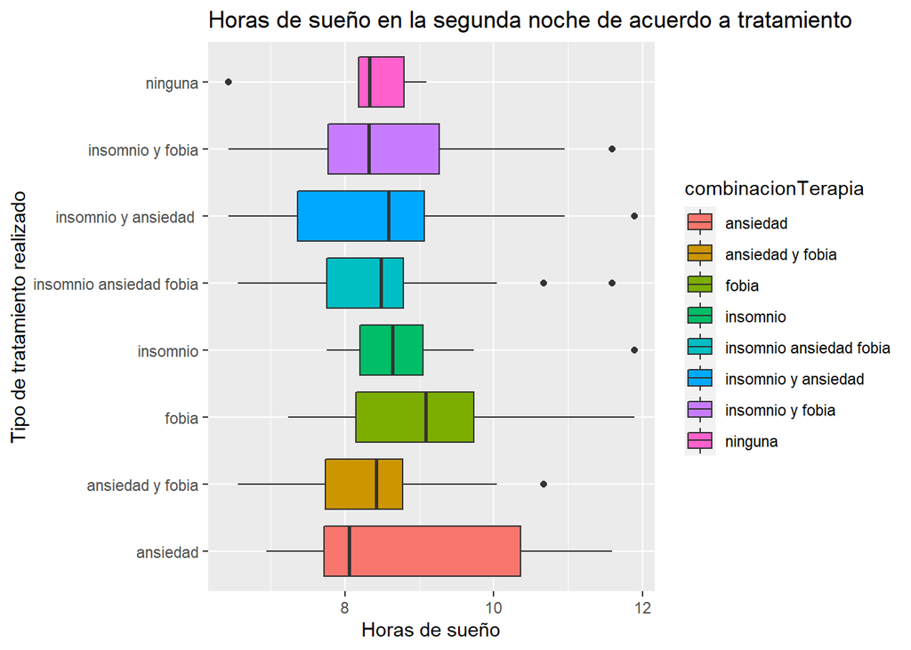

```r
ggplot(dataInsomnio, aes(combinacionTerapia, SegundaNoche, fill = combinacionTerapia)) +
    geom_boxplot() +
    ggtitle("Horas de sueño en la segunda noche de acuerdo a tratamiento") +
    ylab("Horas de sueño") +
    xlab("Tipo de tratamiento realizado") +
    coord_flip()
```

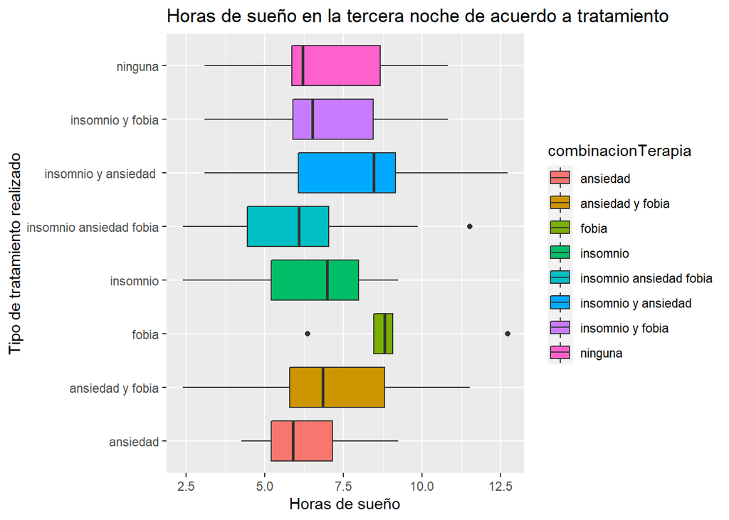

```r
ggplot(dataInsomnio, aes(combinacionTerapia, TerceraNoche, fill = combinacionTerapia)) +
    geom_boxplot() +
    ggtitle("Horas de sueño en la tercera noche de acuerdo a tratamiento") +
    ylab("Horas de sueño") +
    xlab("Tipo de tratamiento realizado") +
    coord_flip()
```

```r
  #theme(axis.text.x = element_text(angle = 45))
```

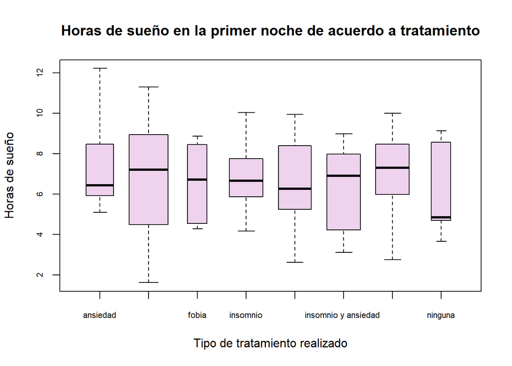

```r
ploot1 <- boxplot(dataInsomnio$PrimerNoche~combinacionTerapia, dataInsomnio, na.action = NULL,
        main = "Horas de sueño en la primer noche de acuerdo a tratamiento",
        ylab = "Horas de sueño",
        xlab = "Tipo de tratamiento realizado",
        ann = TRUE,
        varwidth = TRUE,
        outline = TRUE,
        cex.axis=0.7,
        col = "thistle2")
```

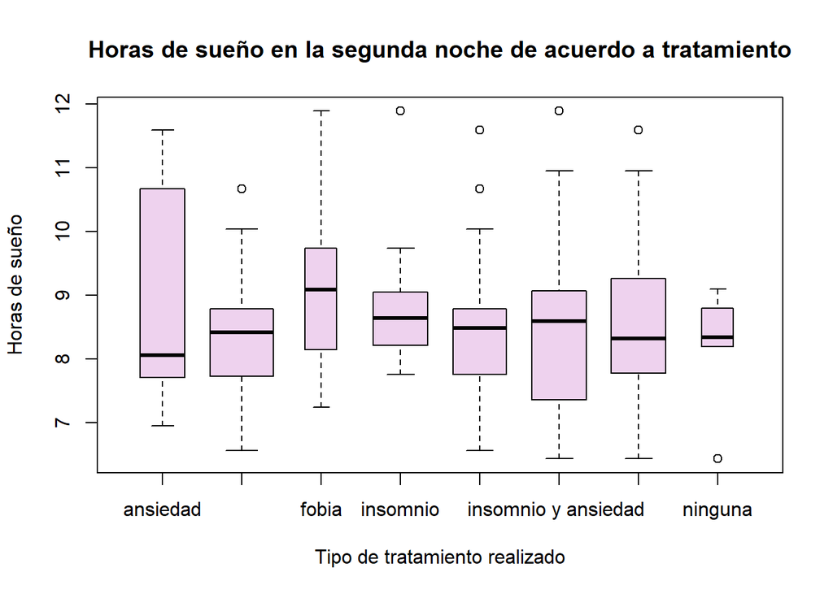

```r
boxplot(dataInsomnio$SegundaNoche~combinacionTerapia, dataInsomnio, na.action = NULL,
        main = "Horas de sueño en la segunda noche de acuerdo a tratamiento",
        ylab = "Horas de sueño",
        xlab = "Tipo de tratamiento realizado",
        ann = TRUE,
        varwidth = TRUE,
        outline = TRUE,
        col = "thistle2")
```

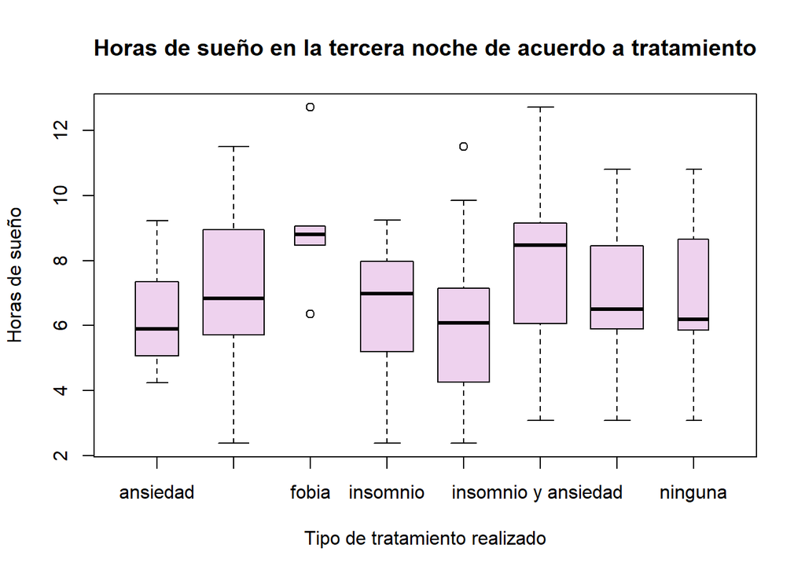

```r
boxplot(dataInsomnio$TerceraNoche~combinacionTerapia, dataInsomnio, na.action = NULL,
        main = "Horas de sueño en la tercera noche de acuerdo a tratamiento",
        ylab = "Horas de sueño",
        xlab = "Tipo de tratamiento realizado",
        ann = TRUE,
        varwidth = TRUE,
        outline = TRUE,
        col = "thistle2")
```